# Natural Earthの地理空間データの可視化

世界，ヨーロッパ州の例

[岩田真一郎](https://shinichiro-iwata.github.io/)（ [神奈川大学経済学部](https://www.econ.kanagawa-u.ac.jp/)）

2022-08-15作成，2025-03-03改訂

# 1 目的

[Natural Earth](https://www.naturalearthdata.com/)は世界各国の無料のベクターデータ（ポイント（点），ライン（線），ポリゴン（面）で地理空間情報を表現）を提供．ここでは，世界の所得分布，ヨーロッパ州の人口分布を示す．世界の所得分布については，座標参照系を変えて，地図を描写する方法も紹介．

- Natural Earthのデータを扱うパッケージが用意されているため，それを利用する．
  - 数値データなどの属性情報も含まれるため，コロプレス図（[階級区分図](https://ja.wikipedia.org/wiki/%E9%9A%8E%E7%B4%9A%E5%8C%BA%E5%88%86%E5%9B%B3)）を作成可能．
  - パッケージをインストールする場合は`install.packages("rnaturalearth")`．

パッケージ：`sf`，`tidyverse`，`rnaturalearth`

```r
library(sf)
library(tidyverse)

#Natural Earth
library(rnaturalearth)
```

# 2 世界地図

**世界地図の読込**

世界地図を可視化．

```r
World_map<-
  ne_countries(scale="medium")
```

とりあえず，世界地図を可視化．

- 座標参照系（CRS）として**地理座標系**EPSG:4326（WGS84）を適用．
  - 座標参照系は地球を球体とみなした地理座標系（緯度，経度）と，地球を平面に投影した**投影座標系**がある．
- （アジアー太平洋が中心にくる）見慣れた地図ではないが，これは経度0度が縦軸の中心（[本初子午線](https://ja.wikipedia.org/wiki/%E6%9C%AC%E5%88%9D%E5%AD%90%E5%8D%88%E7%B7%9A)）に描かれているため．
  - 緯度0度が横軸の中心（[赤道](https://ja.wikipedia.org/wiki/%E8%B5%A4%E9%81%93)）.
  - 高緯度に位置する地物ほど横に広がる（南極が横に広がったり，緯度が相対的に高いグルーランドが相対的に低いオーストリアと同じような大きさに．）
  - アジアー太平洋中心の地図は下記のアジアー太平洋中心を参照．

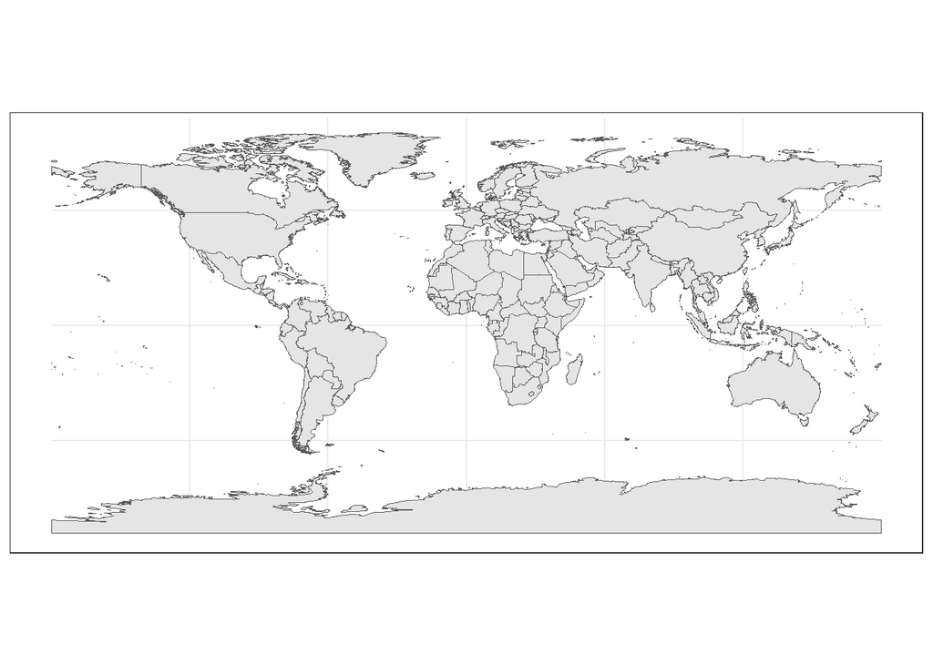

```r
ggplot()+
  geom_sf(data=World_map)+
  theme_bw()
```

**データの中身**

```r
#最初の6行
World_map %>%
  head()
```

|  | featurecla | scalerank | labelrank | sovereignt | sov_a3 | adm0_dif | level | type | tlc | admin | adm0_a3 | geou_dif | geounit | gu_a3 | su_dif | subunit | su_a3 | brk_diff | name | name_long | brk_a3 | brk_name | brk_group | abbrev | postal | formal_en | formal_fr | name_ciawf | note_adm0 | … |
| --- | --- | --- | --- | --- | --- | --- | --- | --- | --- | --- | --- | --- | --- | --- | --- | --- | --- | --- | --- | --- | --- | --- | --- | --- | --- | --- | --- | --- | --- | --- |
| 1 | Admin-0 country | 1 | 3 | Zimbabwe | ZWE | 0 | 2 | Sovereign country | 1 | Zimbabwe | ZWE | 0 | Zimbabwe | ZWE | 0 | Zimbabwe | ZWE | 0 | Zimbabwe | Zimbabwe | ZWE | Zimbabwe | NA | Zimb. | ZW | Republic of Zimbabwe | NA | Zimbabwe | NA | … |
| 2 | Admin-0 country | 1 | 3 | Zambia | ZMB | 0 | 2 | Sovereign country | 1 | Zambia | ZMB | 0 | Zambia | ZMB | 0 | Zambia | ZMB | 0 | Zambia | Zambia | ZMB | Zambia | NA | Zambia | ZM | Republic of Zambia | NA | Zambia | NA | … |
| 3 | Admin-0 country | 1 | 3 | Yemen | YEM | 0 | 2 | Sovereign country | 1 | Yemen | YEM | 0 | Yemen | YEM | 0 | Yemen | YEM | 0 | Yemen | Yemen | YEM | Yemen | NA | Yem. | YE | Republic of Yemen | NA | Yemen | NA | … |
| 4 | Admin-0 country | 3 | 2 | Vietnam | VNM | 0 | 2 | Sovereign country | 1 | Vietnam | VNM | 0 | Vietnam | VNM | 0 | Vietnam | VNM | 0 | Vietnam | Vietnam | VNM | Vietnam | NA | Viet. | VN | Socialist Republic of Vietnam | NA | Vietnam | NA | … |
| 5 | Admin-0 country | 5 | 3 | Venezuela | VEN | 0 | 2 | Sovereign country | 1 | Venezuela | VEN | 0 | Venezuela | VEN | 0 | Venezuela | VEN | 0 | Venezuela | Venezuela | VEN | Venezuela | NA | Ven. | VE | Bolivarian Republic of Venezuela | República Bolivariana de Venezuela | Venezuela | NA | … |
| 6 | Admin-0 country | 6 | 6 | Vatican | VAT | 0 | 2 | Sovereign country | 1 | Vatican | VAT | 0 | Vatican | VAT | 0 | Vatican | VAT | 0 | Vatican | Vatican | VAT | Vatican | NA | Vat. | V | State of the Vatican City | NA | Holy See (Vatican City) | NA | … |

# 3 世界地図上への所得分布の可視化

上の表を右側に進むと，所得を階級分けした列（`income_grp`）が現れる．

- とりあえず，世界地図上へこれを可視化．
  - 各国の枠（`color`）は白（`white`）に指示．
- 凡例を図の下に移動（`legend.position="bottom"`）し，2行にする（`guide_legend(nrow=2)`）．
- 出典を地図の隅に示す（`caption`）．

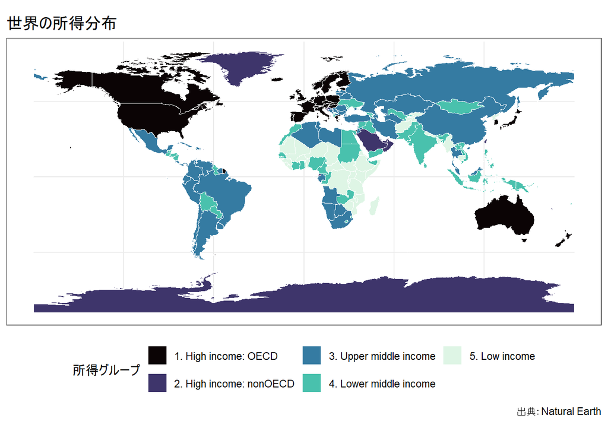

```r
ggplot()+
  geom_sf(data=World_map, aes(fill=income_grp),
          color="white")+
  scale_fill_viridis_d(option="G")+
  labs(fill="所得グループ",
       caption="出典：Natural Earth")+
  ggtitle("世界の所得分布")+
  theme_bw()+
  theme(legend.position="bottom")+
  guides(fill=guide_legend(nrow=2))
```

# 4 応用

## 4.1 投影座標系の適用

投影座標系を適用した座標参照系（CRS）に基づき，世界地図に所得分布を可視化．

### 4.1.1 ロビンソン図法

- 見た目が良く，世界地図に用いられる投影法の1つである[ロビンソン図法](https://ja.wikipedia.org/wiki/%E3%83%AD%E3%83%93%E3%83%B3%E3%82%BD%E3%83%B3%E5%9B%B3%E6%B3%95)（Robinson projection）を利用．
  - `coord_sf()`で`+proj=robin`を指示．`robin`はロビンソン図法のこと．
    - ESRI：[54030](https://spatialreference.org/ref/esri/54030/)に対応．
    - [World Map](https://rpubs.com/mdavril_gsu/794598)（アクセス日：2022-08-15）のBasic Examplesを参照した．

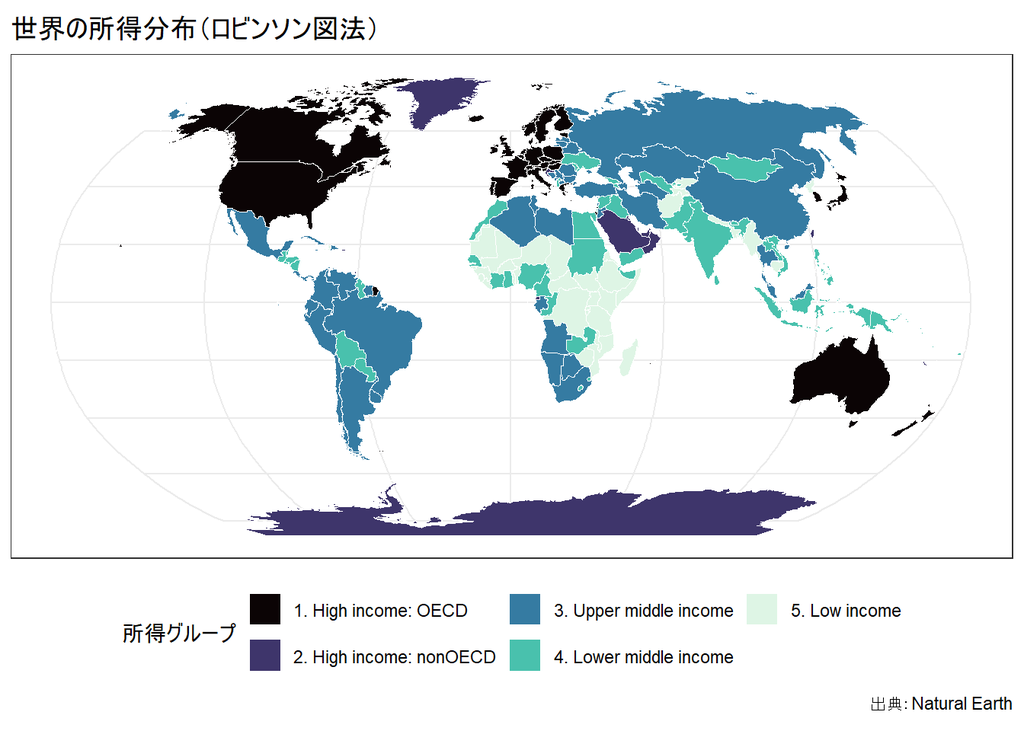

```r
ggplot()+
  geom_sf(data=World_map, aes(fill=income_grp),
          color="white", size=0.001)+
  scale_fill_viridis_d(option="G")+
  labs(fill="所得グループ",
       caption="出典：Natural Earth")+
  ggtitle("世界の所得分布（ロビンソン図法）")+
  theme_bw()+
  coord_sf(crs="+proj=robin")+
  theme(legend.position="bottom")+
  guides(fill=guide_legend(nrow=2))
```

### 4.1.2 モルワイデ図法

- [モルワイデ図法](https://ja.wikipedia.org/wiki/%E3%83%A2%E3%83%AB%E3%83%AF%E3%82%A4%E3%83%87%E5%9B%B3%E6%B3%95)：面積を正しく表現する地図投影法．
  - 形状は歪む．特に地図の周辺部．
    - `moll`：モルワイデ図法．

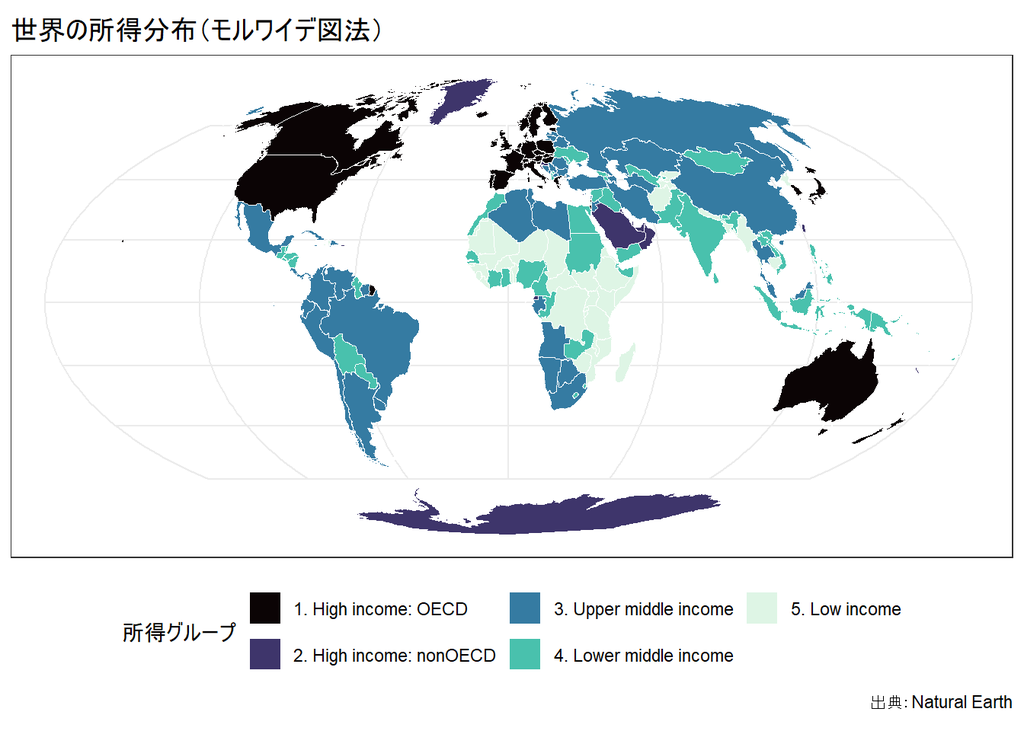

```r
ggplot()+
  geom_sf(data=World_map, aes(fill=income_grp),
          color="white", size=0.001)+
  scale_fill_viridis_d(option="G")+
  labs(fill="所得グループ",
       caption="出典：Natural Earth")+
  ggtitle("世界の所得分布（モルワイデ図法）")+
  theme_bw()+
  coord_sf(crs="+proj=moll")+
  theme(legend.position="bottom")+
  guides(fill=guide_legend(nrow=2))
```

### 4.1.3 ランベルト正積方位図法

- [ランベルト正積方位図法](https://ja.wikipedia.org/wiki/%E3%83%A9%E3%83%B3%E3%83%99%E3%83%AB%E3%83%88%E6%AD%A3%E7%A9%8D%E6%96%B9%E4%BD%8D%E5%9B%B3%E6%B3%95)（Lambert equal area azimuthal projection, `laea`）を利用．
  - 面積は正しく保たれるが，形状は歪む傾向．
  - `coord_sf()`に`crs`を`EPSG:3035`（ヨーロッパ州中心）と指示．
  - EPSG:[3035](https://spatialreference.org/ref/epsg/3035/)．
  - `"+proj=laea +lat_0=52 +lon_0=10"`でもよい．

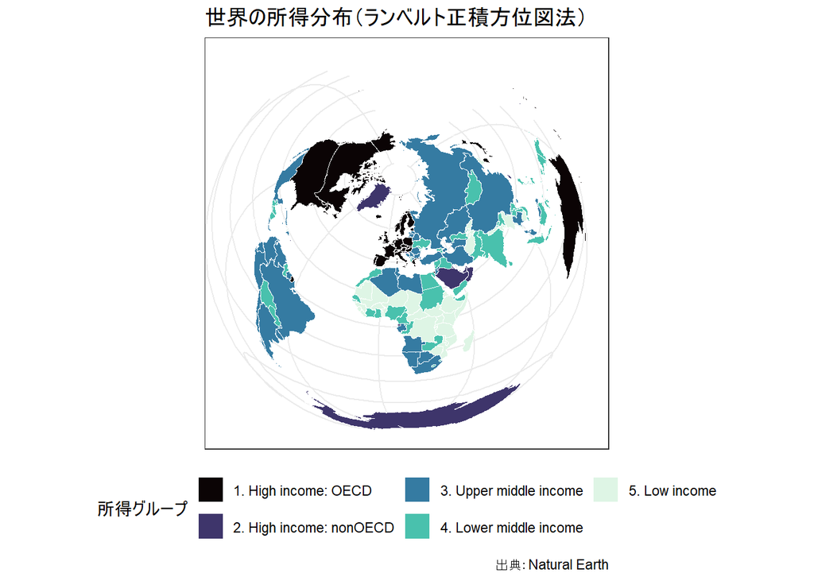

```r
ggplot() +
  geom_sf(data=World_map, aes(fill=income_grp),
          color="white") +
  scale_fill_viridis_d(option="G") +
  labs(fill="所得グループ", caption="出典：Natural Earth") +
  ggtitle("世界の所得分布（ランベルト正積方位図法）") +
  theme_bw() +
  coord_sf(crs=st_crs("EPSG:3035"))+
  theme(legend.position="bottom") +
  guides(fill=guide_legend(nrow=2))
```

### 4.1.4 アジアー太平洋中心

**イコールアース図法**

- 次に中心を本初子午線ではなく，アジアー太平洋を中心とした地図（[イコールアース図法](https://ja.wikipedia.org/wiki/%E3%82%A4%E3%82%B3%E3%83%BC%E3%83%AB%E3%82%A2%E3%83%BC%E3%82%B9%E5%9B%B3%E6%B3%95)）に変更．
  - イコールアース図法はロビンソン図法に近い形状．
- 可視化すると，グリーンランドが横に広がりすぎるので，この地図では削除．

```r
World_map %>%
  filter(iso_a3!="GRL") ->
  Asia_Pacific_map
```

- ESRI：[53037](https://spatialreference.org/ref/esri/53037/)（EPSGの場合[8859](https://spatialreference.org/ref/epsg/8859/)）．
  - `coord_sf()`に`crs`を`ESRI:53037`と指示．

**アジアー太平洋を中心とした地図の可視化**

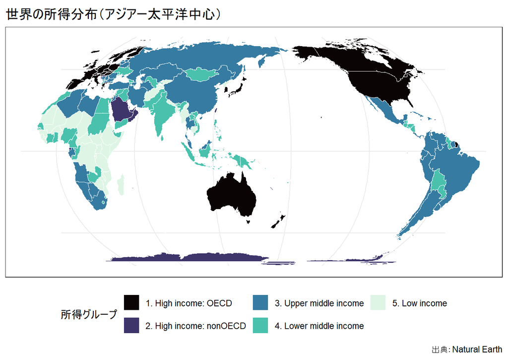

```r
ggplot()+
  geom_sf(data=Asia_Pacific_map, aes(fill=income_grp),
          color="white")+
  scale_fill_viridis_d(option="G")+
  labs(fill="所得グループ",
       caption="出典：Natural Earth")+
  ggtitle("世界の所得分布（アジアー太平洋中心）")+
  theme_bw()+
  coord_sf(crs=st_crs("ESRI:53037"))+
  theme(legend.position="bottom")+
  guides(fill=guide_legend(nrow=2))
```

**ランベルト正積方位図法**

- アジアー太平洋中心のランベルト正積方位図法（`laea`）に対応する EPSGコードは存在しない模様．
  - そこで，[Geocomputation with R](https://r.geocompx.org/jp/index.html)の[7.9 カスタム地図投影法](https://r.geocompx.org/jp/reproj-geo-data.html#mapproj)（アクセス日：2025-03-01）を参考に中心点を東京方向へ移動．
    - `laea`：ランベルト正積方位図法．
    - `+lon_0=140 +lat_0=36`：経度（東経）140°，緯度（北緯）36°方向へ．

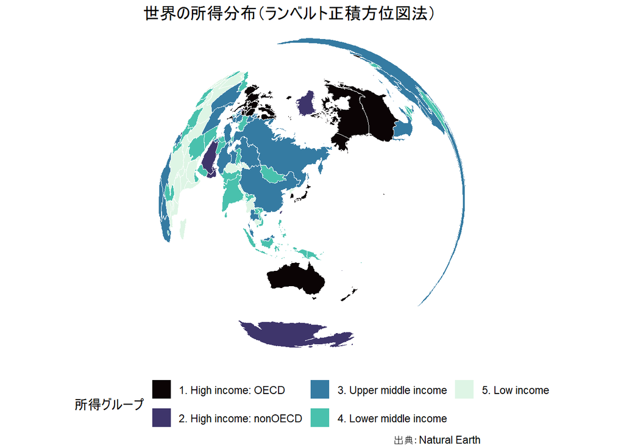

```r
ggplot() +
  geom_sf(data=World_map, aes(fill=income_grp),
          color="white") +
  scale_fill_viridis_d(option="G") +
  labs(fill="所得グループ",
       caption="出典：Natural Earth") +
  ggtitle("世界の所得分布（ランベルト正積方位図法）") +
  theme_void() +
  coord_sf(crs=st_crs(
    "+proj=laea +lon_0=140 +lat_0=36")) +
  theme(legend.position="bottom") +
  guides(fill=guide_legend(nrow=2))
```

## 4.2 ヨーロッパ州の人口分布

**ヨーロッパ州の選抜**

世界地図からヨーロッパ州に属する国を切り抜く（`filter()`）．

- 大陸の識別は上の表で`continent`の列．
  - `Europe_map`と名付ける．

```r
World_map %>%
  filter(continent=="Europe") ->
  Europe_map
```

**ヨーロッパ州地図**

国名（英字２桁の国名コード）を記した地図を作成する．

- `R`コードは示さない．

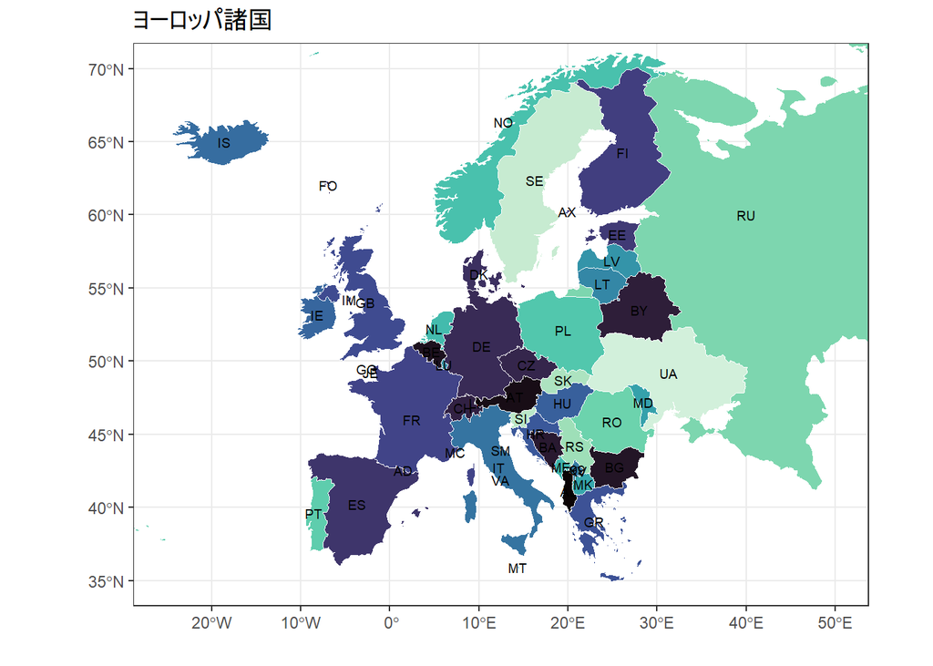

**人口分布**

上の表を右側に進むと，人口（人）を示す（`pop_est`）が現れる．

- これを可視化．
  - 人口は100万で割り，単位を百万人にする．

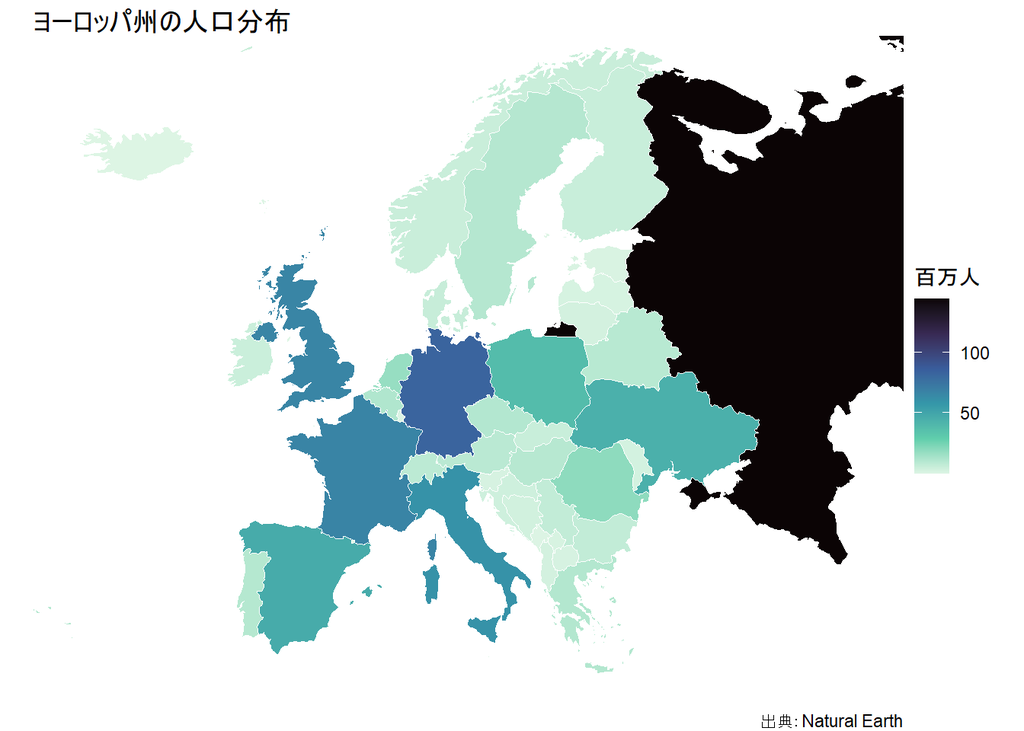

```r
ggplot()+
  geom_sf(data=Europe_map, aes(fill=pop_est/1000000),
          color="white")+
  scale_fill_viridis_c(option="G", direction=-1)+
  labs(fill="百万人",
       caption="出典：Natural Earth")+
  ggtitle("ヨーロッパ州の人口分布")+
  coord_sf(xlim = c(-25,50), ylim = c(35,70))+
  theme_void()
```

**参考ウェブサイト**

[私たちのR: ベストプラクティスの探究](https://www.jaysong.net/RBook/)–[20.11.1 世界地図](https://www.jaysong.net/RBook/visualization4.html#%E4%B8%96%E7%95%8C%E5%9C%B0%E5%9B%B3)（アクセス日：2022-08-14）

[World Map](https://rpubs.com/mdavril_gsu/794598)–Basic Example（アクセス日：2022-08-15）

[Geocomputation with R](https://r.geocompx.org/jp/index.html)–[7.9 カスタム地図投影法](https://r.geocompx.org/jp/reproj-geo-data.html#mapproj)（アクセス日：2025-03-01）

**Rによる地理空間データの可視化**

- チュートリアル[ホーム](https://shinichiro-iwata.github.io/geospatial-data-visualization/)

**アイコン**

[Font Awesome](https://fontawesome.com/) 6.7.2

**生成AIの使用について**

ChatGPTのサービスを利用した後，内容を確認し，必要に応じて編集を行った．